# Data Education Workshop 1

## Logistic Regression:

### Diabetes:

*Data Source:* [UCI Machine Learning Repository](https://archive.ics.uci.edu/ml/index.php) We will be using the features available in this dataset to predict diabetes diagnosis [**Classification** aka **Logistic Regression**!]

```r
diabetes <- read.csv(file="diabetes_data_upload.csv")
head(diabetes)
```

```
##   Age Gender Polyuria Polydipsia sudden.weight.loss weakness Polyphagia
## 1  40   Male       No        Yes                 No      Yes         No
## 2  58   Male       No         No                 No      Yes         No
## 3  41   Male      Yes         No                 No      Yes        Yes
## 4  45   Male       No         No                Yes      Yes        Yes
## 5  60   Male      Yes        Yes                Yes      Yes        Yes
## 6  55   Male      Yes        Yes                 No      Yes        Yes
##   Genital.thrush visual.blurring Itching Irritability delayed.healing
## 1             No              No     Yes           No             Yes
## 2             No             Yes      No           No              No
## 3             No              No     Yes           No             Yes
## 4            Yes              No     Yes           No             Yes
## 5             No             Yes     Yes          Yes             Yes
## 6             No             Yes     Yes           No             Yes
##   partial.paresis muscle.stiffness Alopecia Obesity    class
## 1              No              Yes      Yes     Yes Positive
## 2             Yes               No      Yes      No Positive
## 3              No              Yes      Yes      No Positive
## 4              No               No       No      No Positive
## 5             Yes              Yes      Yes     Yes Positive
## 6              No              Yes      Yes     Yes Positive
```

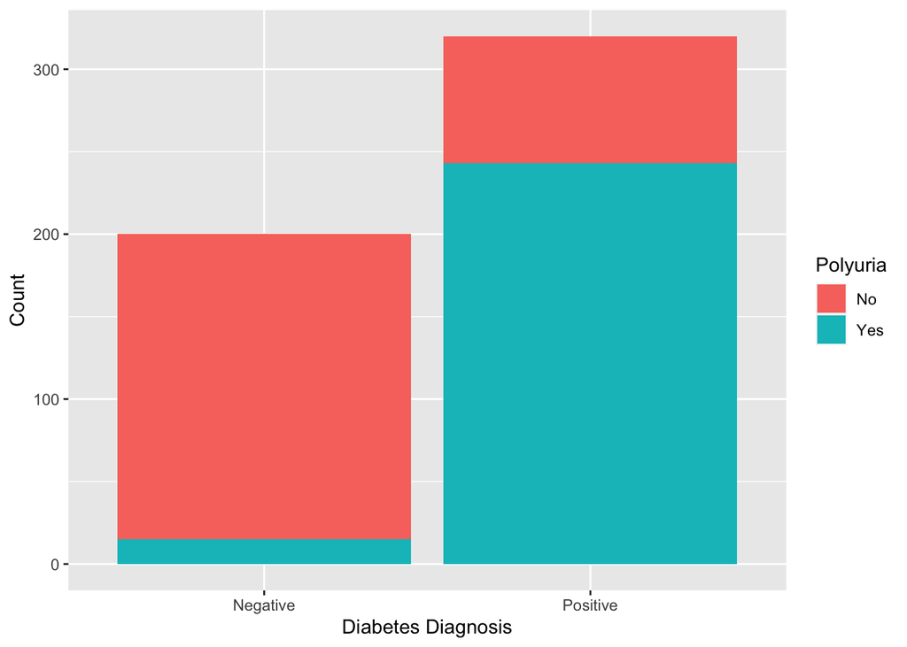

```r
#good predictors!
ggplot(diabetes, aes(x=as.factor(class), fill=Polyuria)) + geom_bar()  + xlab("Diabetes Diagnosis") + ylab("Count")
```

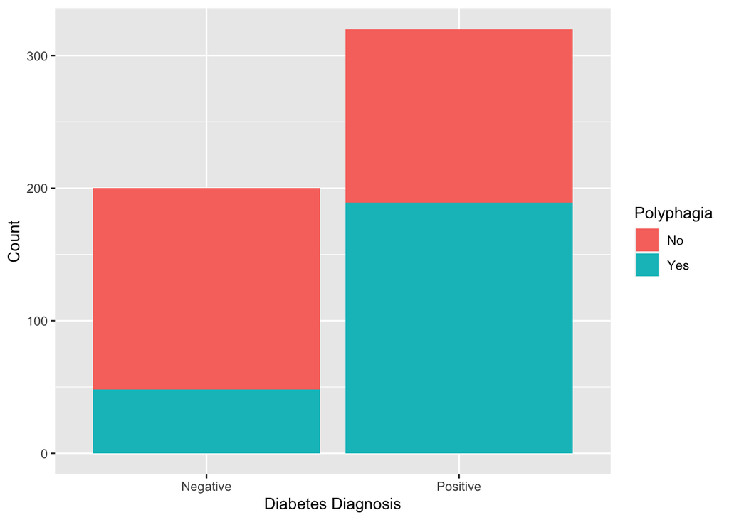

```r
ggplot(diabetes, aes(x=as.factor(class), fill=Polyphagia)) + geom_bar()  + xlab("Diabetes Diagnosis") + ylab("Count")
```

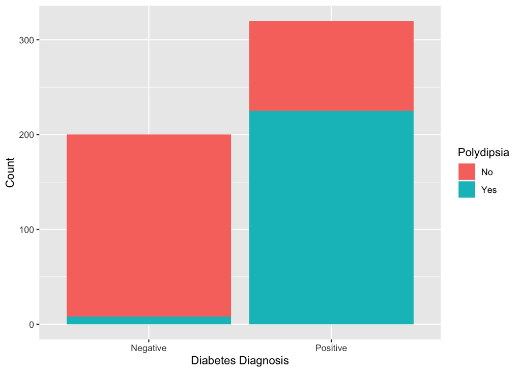

```r
ggplot(diabetes, aes(x=as.factor(class), fill=Polydipsia)) + geom_bar()  + xlab("Diabetes Diagnosis") + ylab("Count")
```

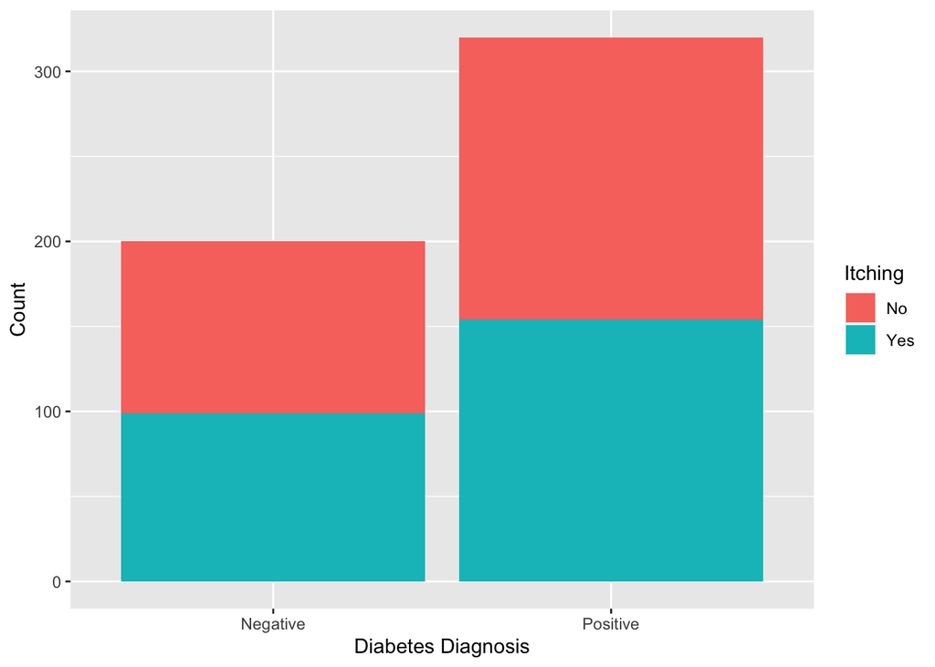

```r
#not so good predictors!
ggplot(diabetes, aes(x=as.factor(class), fill=Itching)) + geom_bar()  + xlab("Diabetes Diagnosis") + ylab("Count")
```

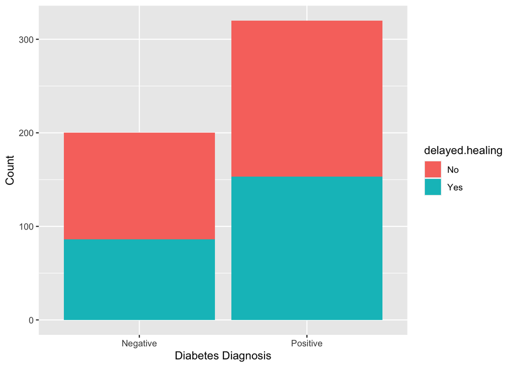

```r
ggplot(diabetes, aes(x=as.factor(class), fill=delayed.healing)) + geom_bar()  + xlab("Diabetes Diagnosis") + ylab("Count")
```

```r
diabetes_1 <- diabetes %>% select(-Age,-class,-Gender)
diabetes_1 <- ifelse(diabetes_1 == "Yes", 1, 0)
diabetes_1 <- as.data.frame(diabetes_1)
diabetes_1 <- diabetes_1 %>% mutate(row.names(diabetes))

diabetes_2 <- diabetes %>% select(Age,class,Gender)
diabetes_2 <- as.data.frame(diabetes_2)
diabetes_2$class <- ifelse(diabetes_2$class == "Positive", 1, 0)
diabetes_2$Gender <- ifelse(diabetes_2$Gender == "Male", 1, 0)
diabetes_2 <- diabetes_2 %>% mutate(row.names(diabetes))


total <- merge(diabetes_1, diabetes_2, by="row.names(diabetes)")
total <- total %>% select(-'row.names(diabetes)')
head(total)
```

```
##   Polyuria Polydipsia sudden.weight.loss weakness Polyphagia Genital.thrush
## 1        0          1                  0        1          0              0
## 2        0          1                  1        1          1              0
## 3        1          1                  0        0          1              1
## 4        1          1                  1        0          1              1
## 5        1          1                  1        1          1              1
## 6        0          1                  1        0          0              1
##   visual.blurring Itching Irritability delayed.healing partial.paresis
## 1               0       1            0               1               0
## 2               1       1            1               0               0
## 3               1       1            0               1               1
## 4               0       0            1               1               0
## 5               1       1            0               1               1
## 6               1       1            0               0               0
##   muscle.stiffness Alopecia Obesity Age class Gender
## 1                1        1       1  40     1      1
## 2                0        1       0  70     1      1
## 3                0        0       0  39     1      0
## 4                1        1       1  48     1      0
## 5                1        0       0  85     1      1
## 6                1        1       0  90     1      0
```

```r
#Set Up Train Set and Test Set
train_set <- total[1:260,]
test_set_0 <- total[260:520,]
test_set <- total[260:520,] %>% select(-class)
new_data <- test_set%>%slice(1:10)

#Create Logistic Model
logistic_model <-glm(class ~ ., family = binomial, train_set)
print(logistic_model)
```

```
##
## Call:  glm(formula = class ~ ., family = binomial, data = train_set)
##
## Coefficients:
##        (Intercept)            Polyuria          Polydipsia  sudden.weight.loss
##            2.46765             4.18916             5.02562             0.04725
##           weakness          Polyphagia      Genital.thrush     visual.blurring
##            0.62874             1.15890             1.78761             1.28891
##            Itching        Irritability     delayed.healing     partial.paresis
##           -2.72260             2.17120            -0.39452             0.77484
##   muscle.stiffness            Alopecia             Obesity                 Age
##           -0.65335             1.44074            -0.07531            -0.07062
##             Gender
##           -3.31890
##
## Degrees of Freedom: 259 Total (i.e. Null);  243 Residual
## Null Deviance:       345.5
## Residual Deviance: 100.8     AIC: 134.8
```

```r
#Predict Test Set Results
predicted <- predict(logistic_model, type = "response",  newdata = new_data)
predicted.class <- ifelse(predicted > 0.5, 1, 0)
predicted.class <- as.factor(predicted.class)
observed <- test_set_0[1:10,]

#Compare to Actual Observed Results
print(predicted)
```

```
##          1          2          3          4          5          6          7
## 0.10096027 0.30527283 0.04880002 0.00577959 0.04424720 0.08496287 0.99997141
##          8          9         10
## 0.99998158 0.99663261 0.99872295
```

```r
print(observed$class)
```

```
##  [1] 0 0 0 0 0 0 1 1 1 1
```

```r
print(predicted.class)
```

```
##  1  2  3  4  5  6  7  8  9 10
##  0  0  0  0  0  0  1  1  1  1
## Levels: 0 1
```

```r
#Input New Values Into Model (Choose Some Values!)
logistic_model_2 <-glm(class ~ Age + Obesity + Gender + Polyuria + Polydipsia + Polyphagia, family = binomial, train_set)
new_data_2 <- data.frame(Age=40, Obesity = 0, Gender = 1, Polyuria = 0, Polydipsia = 1, Polyphagia = 1)
predicted_2 <- predict(logistic_model_2, newdata = new_data_2, type="response")
predicted.class.2 <- ifelse(predicted_2 > 0.5, 1, 0)

#Prediction of diabetes diagnosis for a  non-obese 40 year old male who has experienced polydispsia and polyphagia but not polyuria.
print(predicted_2)
```

```
##         1
## 0.8999348
```

```r
print(predicted.class.2)
```

```
## 1
## 1
```

## Linear Regression

### NHANES Study:

The NHANES I Epidemiologic Follow-up Study (NHEFS) is a national longitudinal study designed to investigate the relationships between clinical, nutritional, and behavioral factors assessed in the first National Health and Nutrition Examination Survey NHANES I and subsequent morbidity, mortality, and hospital utilization, as well as changes in risk factors, functional limitation, and institutionalization.

*Data Source:* [CDC: NHANES Study, NHEFS Dataset](https://wwwn.cdc.gov/nchs/nhanes/nhefs/default.aspx/) We will be using the features available in this dataset to predict systolic blood pressure (which is a continuous outcome) [**Regression Predictive Modeling** aka **Linear Regression**!]

```r
data <- read_excel("nhefs.xlsx")
attach(data)
```

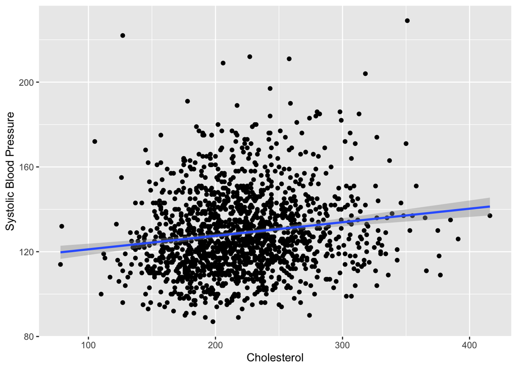

```r
ggplot(data, aes(x=cholesterol, y=sbp)) + geom_point()  + xlab("Cholesterol") + ylab("Systolic Blood Pressure") + geom_smooth(method=lm)
```

[figure not shown]

```r
ggplot(data, aes(x=age, y=sbp)) + geom_point()  + xlab("Cholesterol") + ylab("Systolic Blood Pressure") + geom_smooth(method=lm)
```

```r
#Set Up Train Set and Test Set
train_set_2 <- data[1:814,]
test_set_0_2 <- data[814:1629,] %>% filter(!is.na(sbp)) %>%filter(!is.na(age)) %>% filter(!is.na(cholesterol))
test_set_2 <- test_set_0_2 %>% select(-sbp)

linear_model <- lm(sbp ~ age + cholesterol, data = train_set_2)

summary(linear_model)
```

```
##
## Call:
## lm(formula = sbp ~ age + cholesterol, data = train_set_2)
##
## Residuals:
##     Min      1Q  Median      3Q     Max
## -49.172 -11.781  -1.848   8.400  93.316
##
## Coefficients:
##              Estimate Std. Error t value Pr(>|t|)
## (Intercept) 101.95035    3.52811  28.897   <2e-16 ***
## age           0.54643    0.05451  10.025   <2e-16 ***
## cholesterol   0.01827    0.01423   1.284      0.2
## ---
## Signif. codes:  0 '***' 0.001 '**' 0.01 '*' 0.05 '.' 0.1 ' ' 1
##
## Residual standard error: 17.71 on 762 degrees of freedom
##   (49 observations deleted due to missingness)
## Multiple R-squared:  0.132,  Adjusted R-squared:  0.1298
## F-statistic: 57.96 on 2 and 762 DF,  p-value: < 2.2e-16
```

```r
linear_predicted <- predict(linear_model, newdata = test_set_2)
linear_predicted <- as.data.frame(linear_predicted)

linear_observed <- test_set_0_2 %>% select(sbp)
linear_predicted[1:10,]
```

```
##  [1] 140.4328 123.9087 127.3151 135.8389 124.0016 120.6467 120.9739 133.3092
##  [9] 137.1176 121.5752
```

```r
linear_observed[1:10,]
```

```
## # A tibble: 10 x 1
##      sbp
##    <dbl>
##  1   112
##  2   126
##  3   138
##  4   120
##  5   120
##  6   112
##  7   122
##  8   120
##  9   107
## 10   111
```

```r
new_df <- test_set_0_2 %>% mutate(prediction = linear_predicted)
new_df <- new_df %>% select(sbp, prediction)


#Mean Absolute Error
((sum(abs(new_df$sbp - new_df$prediction)))/ 772)
```

```
## [1] 13.71362
```

```r
#13.71362
```

Lets try to refine our model by adding some more variables…

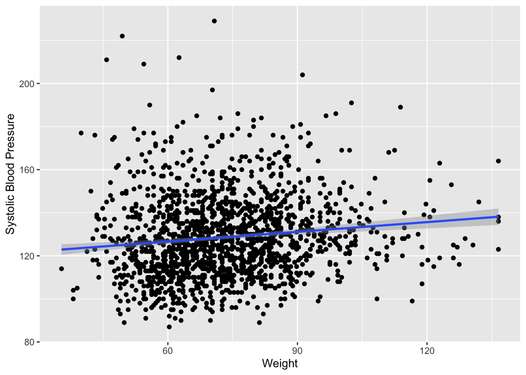

```r
ggplot(data, aes(x=wt82, y=sbp)) + geom_point()  + xlab("Weight") + ylab("Systolic Blood Pressure") + geom_smooth(method=lm)
```

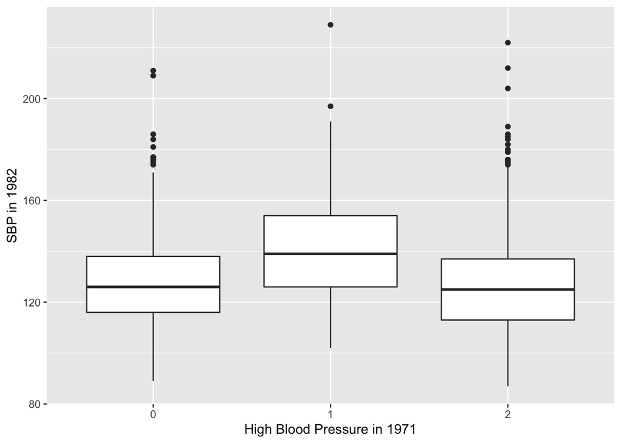

```r
ggplot(data, aes(x=as.factor(hbp), y=sbp)) + geom_boxplot()  + xlab("High Blood Pressure in 1971") + ylab("SBP in 1982")
```

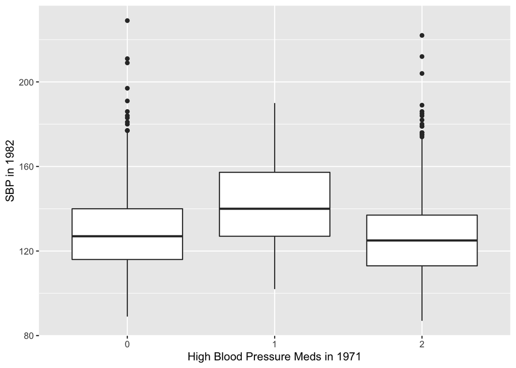

```r
ggplot(data, aes(x=as.factor(hbpmed), y=sbp)) + geom_boxplot()  + xlab("High Blood Pressure Meds in 1971") + ylab("SBP in 1982")
```

```r
#Set Up Train Set and Test Set
train_set_2.1 <- data[1:814,]
test_set_0_2.1 <- data[814:1629,] %>% filter(!is.na(sbp)) %>%filter(!is.na(age)) %>% filter(!is.na(sex)) %>% filter(!is.na(race)) %>% filter(!is.na(wt82)) %>% filter(!is.na(hbp)) %>% filter(!is.na(cholesterol)) %>% filter(!is.na(hbpmed))
test_set_0_2.1 <- test_set_0_2.1 %>% filter(hbpmed !=2) %>% filter(hbp !=2)
test_set_2.1 <- test_set_0_2.1 %>% select(-sbp)

linear_model_2 <- lm(sbp ~ age + sex + race + wt82 + cholesterol + as.factor(hbpmed) + as.factor(hbp), data = train_set_2.1)

summary(linear_model_2)
```

```
##
## Call:
## lm(formula = sbp ~ age + sex + race + wt82 + cholesterol + as.factor(hbpmed) +
##     as.factor(hbp), data = train_set_2.1)
##
## Residuals:
##     Min      1Q  Median      3Q     Max
## -46.339 -11.185  -2.333   8.545  84.949
##
## Coefficients:
##                    Estimate Std. Error t value Pr(>|t|)
## (Intercept)        94.44242    4.99390  18.912  < 2e-16 ***
## age                 0.51519    0.05572   9.246  < 2e-16 ***
## sex                -3.25611    1.37399  -2.370   0.0180 *
## race                3.93620    1.76788   2.227   0.0263 *
## wt82                0.11111    0.04306   2.580   0.0101 *
## cholesterol         0.01968    0.01400   1.405   0.1603
## as.factor(hbpmed)1 -1.39080    3.11768  -0.446   0.6557
## as.factor(hbp)1     9.08022    2.17017   4.184  3.2e-05 ***
## ---
## Signif. codes:  0 '***' 0.001 '**' 0.01 '*' 0.05 '.' 0.1 ' ' 1
##
## Residual standard error: 17.13 on 748 degrees of freedom
##   (58 observations deleted due to missingness)
## Multiple R-squared:  0.1908, Adjusted R-squared:  0.1832
## F-statistic:  25.2 on 7 and 748 DF,  p-value: < 2.2e-16
```

```r
linear_predicted_2 <- predict(linear_model_2, newdata = test_set_2.1)
linear_predicted_2 <- as.data.frame(linear_predicted_2)

new_df_2 <- test_set_0_2.1 %>% mutate(prediction = linear_predicted_2)
new_df_2 <- new_df_2 %>% select(sbp, prediction)

#Mean Absolute Error
((sum(abs(new_df_2$sbp - new_df_2$prediction)))/ 24)
```

```
## [1] 12.4005
```

```r
#12.4005

#Slightly more accurate!
```